# Data science per psicologi - demo 14.02

Corrado Caudek

2022-03-29

```r
suppressPackageStartupMessages({
  library("here")
  library("tidyverse")
  library("scales")
  library("bayesplot")
  library("distrEx")
})

theme_set(bayesplot::theme_default(base_size = 12))
bayesplot::color_scheme_set("gray")
set.seed(84735)

knitr::opts_chunk$set(
  collapse = TRUE,
  tidy = 'styler',
  fig.width = 6,
  fig.asp = 0.618 # 1 / phi
)
```

# Funzione di verosimiglianza Gaussiana

La funzione di verosmiglianza è la funzione di massa o di densità di probabilità dei dati $y$ vista come una funzione del parametro sconosciuto (o dei parametri sconosciuti) $\theta$. Nel tutorial precedente abbiamo visto come costruire la funzione di verosimiglianza nel caso di un modello Binomiale. Consideriamo qui il modello gaussiano:

$${\displaystyle f(x)={\frac {1}{\sigma {\sqrt {2\pi }}}}e^{-{\frac
{1}{2}}\left({\frac {x-\mu }{\sigma }}\right)^{2}}}.$$

Ci poniamo il problema di costruire la funzione di verosimiglianza per questa funzione di densità di probabilità.

## Una singola osservazione

Consideriamo prima il caso in cui i dati corrispondono ad una singola osservazione $x$. La formula precedente dipende dai parametri $\mu$ e $\sigma$ e dai dati $x$. Per costruire la funzione di verosimiglianza, dobbiamo dunque inserire nella formula precedente un singolo valore $x$. In output abbiamo il risultato che si ottiene variando, nella funzione, i valori di due parametri: $\mu$ e $\sigma$.

Per semplicità, consideriamo il caso in cui si ipotizza $\sigma$ noto e uguale a 15. Poniamo $x = 114$.

```r
x <- 114
```

Esamineremo qui l’andamento della funzione nell’intervallo di valori $\mu$ compreso tra 70 e 160:

```r
mu <- seq(70, 160, length.out = 1e3)
```

La formula della distribuzione Gaussiana è implementata in $\mathsf{R}$ nella funzione `dnorm()`. La funzione `dnorm()` ha tre argomenti:

- il valore $x$ (o il vettore $x$),
- la media, ovvero il parametro $\mu$,
- la deviazione standard, ovvero il parametro $\sigma$.

Come nel caso della Binomiale, anche ora, per calcolare la funzione di verosimiglianza, teniamo costante i dati – nel caso presente, il singolo valore $x = 114$, e facciamo variare il valore dei parametri – qui, solo $\mu$, dato che il parametro $\sigma$ è assunto noto, $\sigma = 15$.

Nella presente simulazione consideriamo 1000 possibile valori del parametro $\mu \in [70, 160]$. Applichiamo dunque 1000 volte la formula della densità Gaussiana, una volta per ciascuno dei 1000 possibili valori $\mu$, tenendo costanti gli altri valori nella formula, ovvero $x = 114$ e $\sigma = 15$. Otteniamo così 1000 punti – ovvero, 1000 coppie di valori $\mu$ e $f(\mu)$. La curva che interpola tali punti è la funzione di verosimiglianza.

```r
f_mu <- dnorm(x, mean = mu, sd = 15)
```

Si noti che la funzione di verosimiglianza ha la forma della distribuzione Gaussiana. Nel caso di una singola osservazione (ma solo in questo caso), ha anche un’area unitaria:

```r
integrand <- function(mu) {
  x <- 114
  sigma <- 15
  dnorm(x, mu, sigma)
}
integrate(integrand, lower = -10000, upper = 10000)
## 1 with absolute error < 1.6e-06
```

La moda di tale funzione è 114:

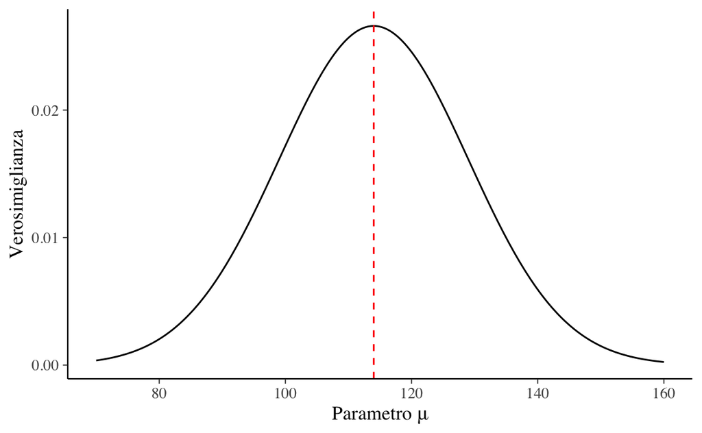

```r
tibble(mu, f_mu) %>%
  ggplot(
    aes(x = mu, y = f_mu)
  ) +
  geom_line() +
  vline_at(114, color = "red", linetype = "dashed") +
  labs(
    y = "Verosimiglianza",
    x = c("Parametro \u03BC")
  )
```

## Un campione di osservazioni

Consideriamo ora il caso di 30 osservazioni indipendenti iid, ciascuna delle quali può essere considerata come la realizzazione di una variabile casuale Gaussiana di media comune sconosciuta e di deviazione standard pari a 15.

```r
n <- 30
true_sigma <- 15
```

Generiamo un campione di dati assumendo che il valore ignoto di $\mu$ sia pari a 100:

```r
set.seed(123)
true_mu <- 100
x <- rnorm(n, true_mu, true_sigma)
x
```

```
##  [1]  91.59287  96.54734 123.38062 101.05763 101.93932 125.72597 106.91374
##  [8]  81.02408  89.69721  93.31507 118.36123 105.39721 106.01157 101.66024
## [15]  91.66238 126.80370 107.46776  70.50074 110.52034  92.90813  83.98264
## [22]  96.73038  84.60993  89.06663  90.62441  74.69960 112.56681 102.30060
## [29]  82.92795 118.80722
```

Supponiamo che questi siano i dati osservati.

Costruiamo ora la funzione di verosimiglianza.

Abbiamo visto in precedenza che, nel caso di due variabili casuali $X_1$ e $X_2$, è la probabilità congiunta è:

$$P(X_1, X_2) = P(X_1) P(X_2 \mid X_1).$$

Se le due variabili casuali sono indipendenti, abbiamo semplicemente

$$P(X_1, X_2) = P(X_1) P(X_2).$$

Possiamo generalizzare tale risultato al caso delle distribuzioni di densità di probabilità. In particolare, nel caso di $n$ v.c. iid, cascuna distribuita come $\mathcal{N}(\mu, \sigma)$, avremo che

$$p(X_1, \dots, X_n ; \mu, \sigma) = \prod p(X_i; \mu, \sigma).$$

Dato che fare il prodotto di 30 valori minori di 1 produce un numero molto piccolo, calcoliamo invece la *log-verosimiglianza*. Il logaritmo della funzione di densità congiunta è dato da una somma:

$$\log p(X_1, \dots, X_n ; \mu, \sigma) = \log \Big( \prod p(X_i; \mu,
\sigma)\Big) = \sum \log p(X_i; \mu, \sigma).$$

Nella funzione di densità congiunta, facciamo nuovamente variare il valore dei parametri (in questo caso, solo $\mu$) e teniamo costante tutto il resto (ovvero, i dati e $\sigma$). Così facendo otteniamo la funzione di log-verosmiglianza che in $\mathsf{R}$ si può scrivere così:

```r
log_likelihood <- function(x, mu, sigma = true_sigma) {
  sum(dnorm(x, mu, sigma, log = TRUE))
}
```

Nel caso presente, i dati sono:

```r
x
```

```
##  [1]  91.59287  96.54734 123.38062 101.05763 101.93932 125.72597 106.91374
##  [8]  81.02408  89.69721  93.31507 118.36123 105.39721 106.01157 101.66024
## [15]  91.66238 126.80370 107.46776  70.50074 110.52034  92.90813  83.98264
## [22]  96.73038  84.60993  89.06663  90.62441  74.69960 112.56681 102.30060
## [29]  82.92795 118.80722
```

Nella simulazione, per generare la figura consideriamo valori $\mu \in [70, 130]$:

```r
nrep <- 1e5
mu <- seq(70, 130, length.out = nrep)
```

Per ciascuno di questi possibili valori del parametro $\mu$ calcoliamo il valore della funzione congiunta di verosimiglianza usando tutte le 30 osservazioni del campione. Salviamo i risultati nel vettore `ll`:

```r
ll <- rep(NA, nrep)
for (i in 1:nrep) {
  ll[i] <- log_likelihood(x, mu[i], true_sigma)
}
```

Possiamo ora generare un grafico della funzione di log-verosimiglianza:

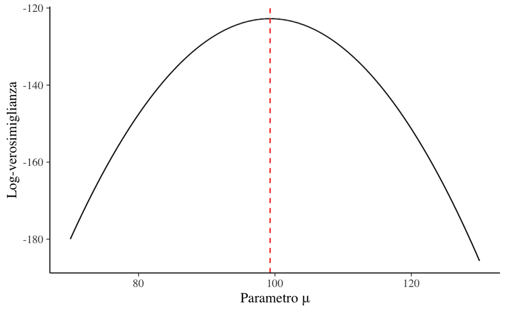

```r
tibble(mu, ll) %>%
  ggplot(
    aes(x = mu, y = ll)
  ) +
  geom_line() +
  vline_at(mean(x), color = "red", linetype = "dashed") +
  labs(
    y = "Log-verosimiglianza",
    x = c("Parametro \u03BC")
  )
```

## Stima di massima verosimiglianza

Troviamo ora la stima di massima verosimiglianza, ovvero il valore del paraemtro che massimizza la funzione di (log-) verosimiglianza:

$$\hat{\mu} = \mbox{arg max}_{\mu} \, \ell (x \mid \mu).$$

```r
mu[which.max(ll)]
```

```
## [1] 99.29349
```

Sappiamo che la stima di massima verosimiglianza coincide con la media del campione. Verifichiamo:

```r
mean(x)
```

```
## [1] 99.29344
```

L’approssimazione deriva dal fatto che abbiamo utilizzato un numero finito di punti.